# index

[figure not shown]

## Objective of the course

> “train young researchers in building and analyzing mathematical models that will help them better understand ecological data”

## Organizers

- Nicolas Casajus (CESAB)
- Vincent Calcagno
- Emanuel A. Fronhofer
- Isabelle Gounand
- Claire Jacquet
- Sonia Kéfi
- François Massol

## Organizers/helpers/guests

- Nicolas Casajus (CESAB)
- Vincent Calcagno
- Emanuel A. Fronhofer
- Isabelle Gounand
- Claire Jacquet
- Sonia Kéfi
- François Massol
- Peter Kamal (Tues)
- Quentin Petitjean (Wed)
- Peter B Adler (Guest Mon)
- Benjamin Rosenbaum (Guest Tues)
- Kevin Painter (Guest Wed)
- Matthieu Barbier (Guest Thu)

## Your turn!

name, position (PhD/post-doc/engineer), institute (location)

## Program of the week: courses

- **Day 1 (9h-17h00): Introduction** to theoretical modeling
  - S. Kéfi, I. Gounand, V. Calcagno
  - Guest: P.B. Adler
- **Day 2 (9h30-17h): Temporal series** and dynamics in ecology
  - E. Fronhofer and P. Kamal
  - Guest: B. Rosenbaum
- **Day 3 (9h-17h): Spatial data**, macro-ecology and co-occurrences
  - V. Calcagno and Q. Petitjean
  - Guest: K. Painter
- **Day 4 (9h-17h): Interaction networks**, trophic networks and complexity in ecology
  - F. Massol, C. Jacquet
  - Guest: M. Barbier
- **Day 5 (9h-17h): Group projects** (mornings), presentations (afternoon)

## Program of today

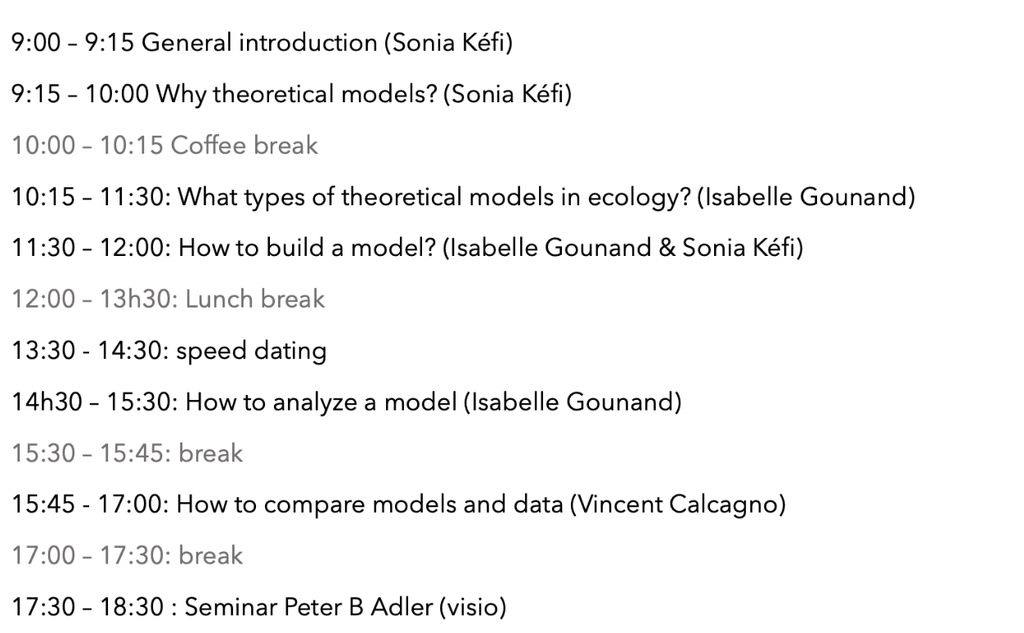

## Big data

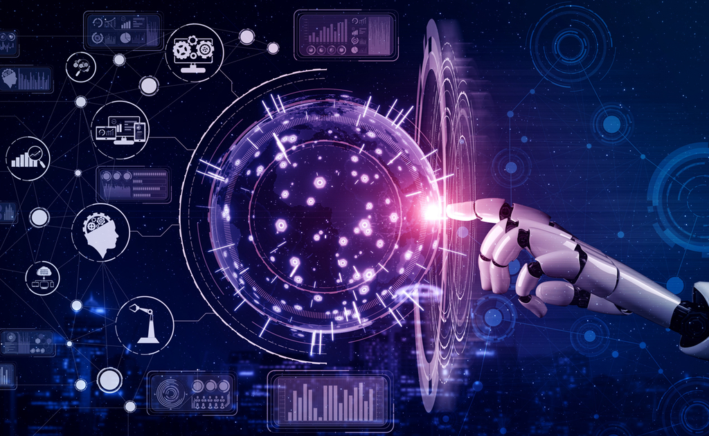

## Big data

[figure not shown]

https://www.theguardian.com/society/2023/apr/30/artificial-intelligence-tool-identify-cancer-ai

## Big data

[figure not shown]

## Big data

Do we still need models and theory?

## What do you mean ‘theory’?

> “Scientific theories contain universal or general propositions regarding the system in question.”

Maris et al., 2017

## What do you mean ‘theory’?

> “The transformation of an idea in narrative form into a logical, testable theory often, though not always, involves the use of models.”

Otto and Rosales, 2020

## What are models?

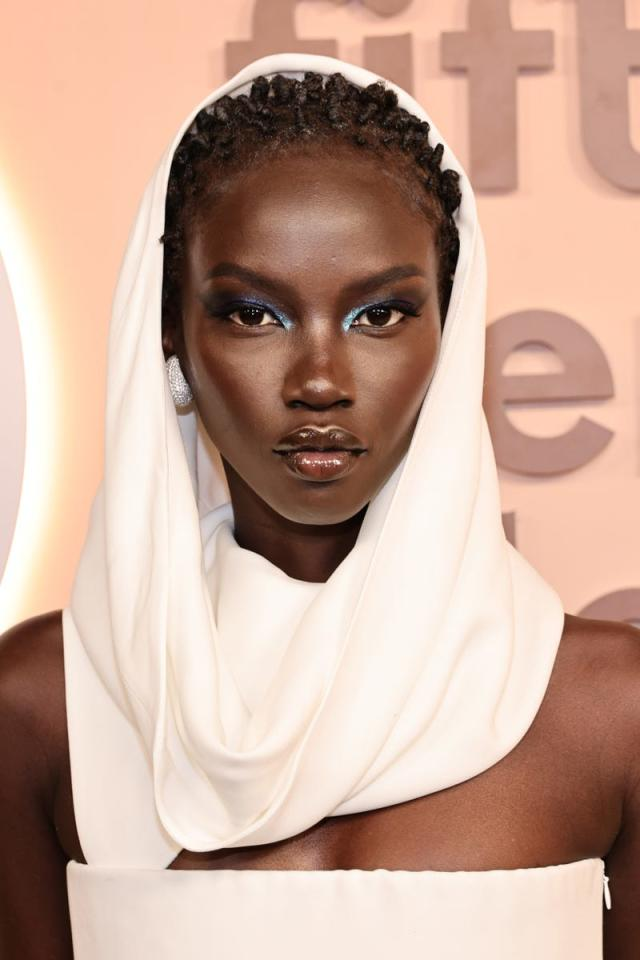

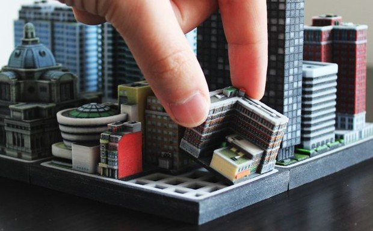

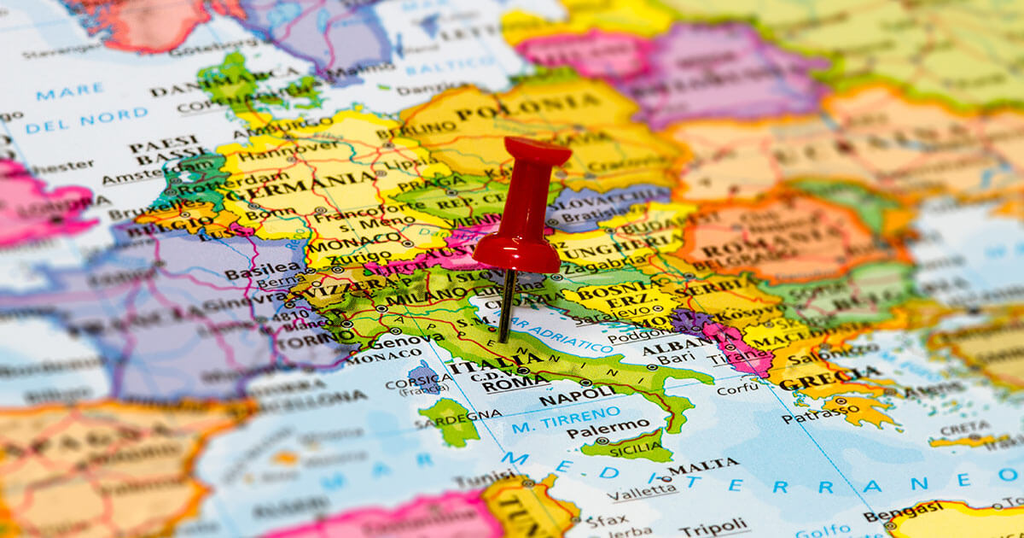

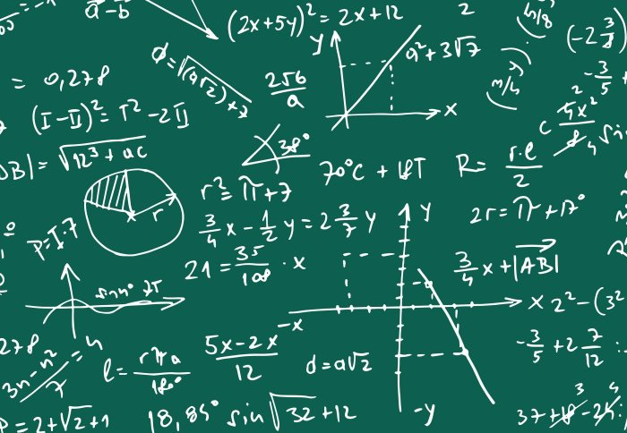

## What are models?

> Models are simplified, idealized representations of reality.

## What are models?

They can be:

- verbal
- conceptual (diagram of boxes and arrows)
- quantitative/mathematical (sets of equations)

## What are models?

Note: Theory and maths are not inexorably linked.

Many excellent theories do not involve maths (e.g., Darwin’s theory of evolution), and many uses of maths in ecology are not theory (e.g., practical applications of statistics).

## What are models?

> “All models are wrong, but some models are useful”

George E.P. Box, 1976

https://en.wikipedia.org/wiki/All_models_are_wrong

## What are models?

Ecological systems are complex…

- How to capture the complexity of reality?
- We can’t!

## What are models?

Modeling implies a **choice** about what to include and what to leave out.

## What are models?

A tension between realism, generality, and precision.

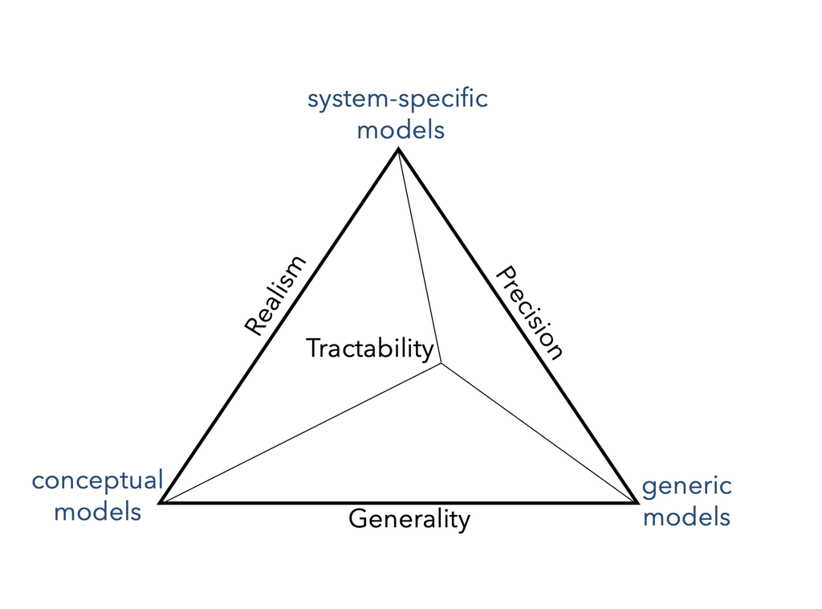

Levins, 1966

## What are models?

An model type classification:

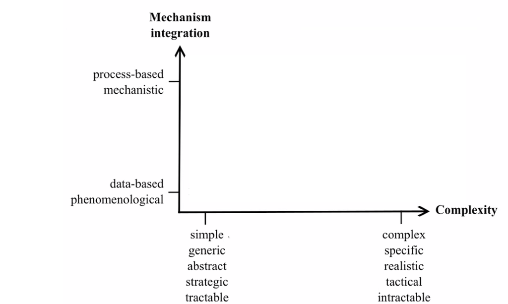

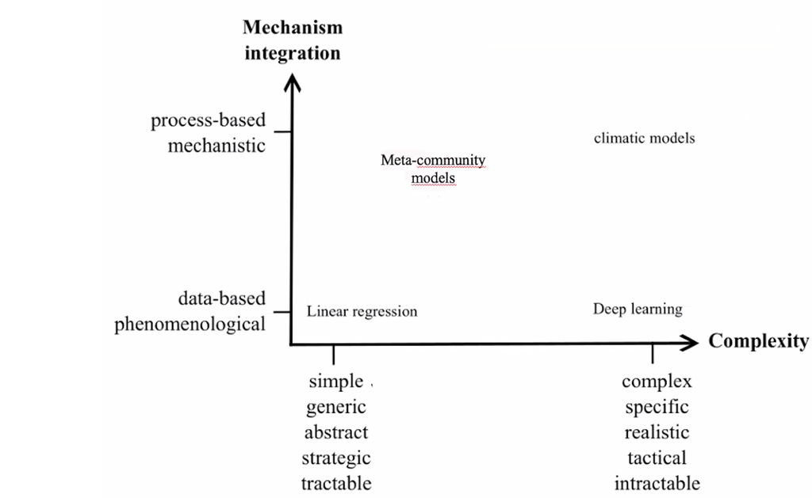

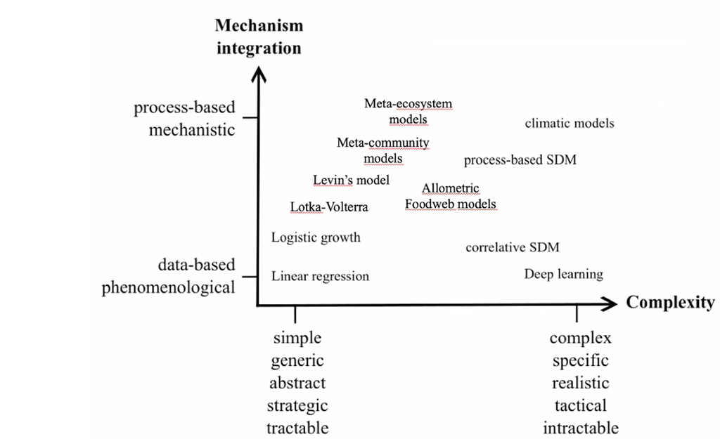

## Why do we need models/theory?

What for?

- **understand**
  - e.g. provide a mechanistic explanation for how plants grow as fast or slowly as they do
- **predict**
  - e.g. make predictions about the population size in the future

## Big data

- reveal correlations
- but correlations are not causality

## Big data

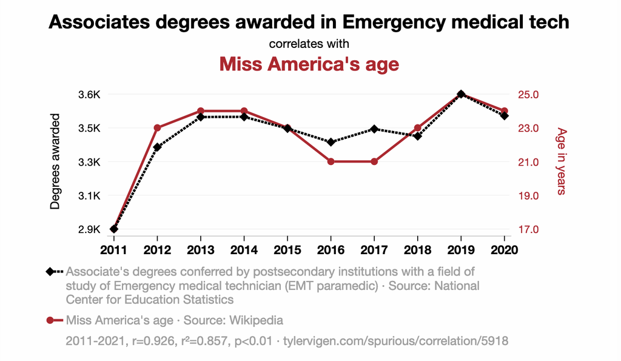

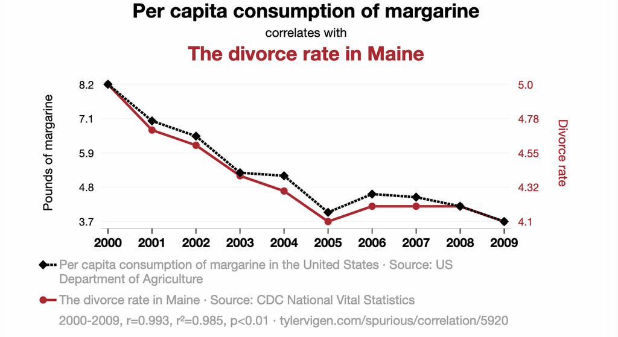

https://www.tylervigen.com/spurious-correlations

## Big data

- do not distinguish causal from non-causal correlations
- do not translate readily into understanding
- can still be predictive!

## Big data

BUT:

- predictions can fail
- predict without understanding…. act without understanding?

## Big data

- do we still need models and theory?
- yes!

## Big data

[figure not shown]

## The scientific method

- problem identification
- hypothesis
- prediction
- testing
- refinement

## The scientific method

- The scientific method is an iterative, cyclical process through which information is continually revised.
- A feedback loop involving data and models.
- > “Perception without conception is blind; conception without perception is empty” Kant, 1781

## BUT

A current disconnection between theoretical and empirical research.

- 45% of articles on empirical ecology make no mention of any theory (Scheiner 2013)
- fewer than 10% of ecologists and evolutionary biologists agree with the statement that ‘theoretical findings drive empirical work’ in their fields (Haller 2014)

## Why this disconnection?

- A lack of theoretical training in ecology (Rossberg et al. 2019).
- A lack of motivation from some theoreticians to engage with the language of empiricists (Grimm 1994) or with the elements of nature that empiricists focus on (Krebs 1988).
- A lack of mutual appreciation between empiricists and theoreticians (Haller 2014).
- Persistent communication barriers (Servedio 2020).
- This barrier presents a major challenge to the full integration of theoretical and empirical work in ecology.
- A better integration of theory into empirical work is needed!
- This is especially important in the context of global change.
  - Hence this course!